# Exploring the BRFSS data

## Setup

### Load packages

```r
library(ggplot2)
library(dplyr)
library(statsr)
library(tidyr)
```

### Load data

Make sure your data and R Markdown files are in the same directory. When loaded your data file will be called `brfss2013`. Delete this note when before you submit your work.

```r
load("brfss2013.RData")
```

## Part 1: Data

### Insights on data collection

#### Generalizability and Causality

- The method in which this data was collected (observational study) appears to make it generalizable to the non-institutionalized Adult population (over 18 years of age.)
- The conclusions arrived at cannot be determined as causal, as random assignment was not utilized.

#### Sampling Method and Potential Biases

- The observational study itself appears to follow a Stratified sampling method.
  - Each state can be considered a strata, and within that strata, random samples are taken.
- In the data collection phase, there could be a few issues.
  - Bias could exist within the sampling method; more interviews may be taken in specific neighborhoods that are of higher or lower income, skewing the overall results. A multi-stage sampling method would likely return more consistent results.
  - There are a substantial more female interviees in the dataset than males.
  - Up until 2001, the data collected would not be reliable, as many states were not taking part in the surveys at that time. It took until 2011 before data from all states were being collected.

## Part 2: Research questions

### Research question 1

#### Which states are the healthiest on average?

- This surface-level question is aimed at identifying which states are the healthiest, based on the genhlth and X_state variables. The sex variable is added to help identify if there is a gap that exists between males and females.

### Research question 2

#### Is there a relationship between general health, income, education level and sex?

- This question, working in conjunction with the first, is to try and answer if there is a relationship between an individuals income, education and overall health. This would tie in with which states are on average, the healthiest.

### Research question 3

#### What is the completion rate of interviews by type and sex?

- This question aims to answer which interview type had the highest completion rate. The sex variable is also included to help differentiate between whether males or females were more likely to finish the interview or not.

## Part 3: Exploratory data analysis

NOTE: Insert code chunks as needed by clicking on the “Insert a new code chunk” button (green button with orange arrow) above. Make sure that your code is visible in the project you submit. Delete this note when before you submit your work.

### Preliminary Data Analysis

```r
#head(brfss2013)
#tail(brfss2013)
#names(brfss2013)
#str(brfss2013)
```

```r
# Keep only relevant columns for analysis
trimmed_brfss2013 <- brfss2013 %>%
  select(c(X_state, genhlth, qstver, dispcode, sex, educa, income2))

#colnames(trimmed_brfss2013)
#View(trimmed_brfss2013)
#glimpse(trimmed_brfss2013)

# Check N/A's
#sapply(trimmed_brfss2013, function(x) sum(is.na(x)))

# Remove rows with N/A's
trimmed_brfss2013 <- na.omit(trimmed_brfss2013)

trimmed_brfss2013 <- rename(trimmed_brfss2013,
  state = X_state,
  gen_hlth = genhlth,
  int_type = qstver,
  compl_type = dispcode,
  sex = sex,
  education = educa,
  income = income2)
```

```r
# Check for biases
table(trimmed_brfss2013$sex)
```

```
##
##   Male Female
## 177290 241113
```

```r
# Compare sex and state
table(trimmed_brfss2013$sex,
trimmed_brfss2013$state)
```

```
##
##              0 Alabama Alaska Arizona Arkansas California Colorado Connecticut
##   Male       0    1842   1957    1557     1720       4624     5327        2803
##   Female     0    3289   2199    2066     2634       5779     6617        3756
##
##          Delaware District of Columbia Florida Georgia Hawaii Idaho Illinois
##   Male       1810                 1719   11466    2832   3316  2159     2211
##   Female     2567                 2538   16914    4368   3775  2770     3082
##
##          Indiana  Iowa Kansas Kentucky Louisiana Maine Maryland Massachusetts
##   Male      3728  2961   8644     2787      1531  3094     4333          5246
##   Female    4892  4126  11475     4685      2773  4203     6565          7418
##
##          Michigan Minnesota Mississippi Missouri Montana Nebraska Nevada
##   Male       4830      5544        2282     2385    3946     6381   1925
##   Female     6146      6980        3928     3477    4705     8741   2431
##
##          New Hampshire New Jersey New Mexico New York North Carolina
##   Male            2229       5023       3586     3226           2860
##   Female          2955       6462       4644     4352           4235
##
##          North Dakota  Ohio Oklahoma Oregon Pennsylvania Rhode Island
##   Male           3180  4250     2909   2287         4200         2258
##   Female         3560  6015     4298   2871         5487         3245
##
##          South Carolina South Dakota Tennessee Texas  Utah Vermont Virginia
##   Male             3832         2667      1549  3763  5117    2388     3098
##   Female           5246         3091      2531  5143  6028    3174     4220
##
##          Washington West Virginia Wisconsin Wyoming  Guam Puerto Rico    80
##   Male         4276          2131      2619    2278   724        1880     0
##   Female       5421          2814      3205    3186   898        3133     0
```

```r
# Compare interview type and completion state
table(trimmed_brfss2013$int_type,
trimmed_brfss2013$compl_type)
```

```
##
##                           Completed interview Partially completed interview
##   Only Version Landline                151509                         12736
##   Version 1 Landline                    60554                          5037
##   Version 2 Landline                    54964                          4708
##   Version 3 Landline                    11502                          1263
##   Only Version Cell Phone               52414                         15445
##   Version 1 Cell Phone                  20254                          3153
##   Version 2 Cell Phone                  17995                          2754
##   Version 3 Cell Phone                   3492                           623
```

```r
# Compare education level and income
table(trimmed_brfss2013$education,
trimmed_brfss2013$income)
```

```
##
##                                                                Less than $10,000
##   Never attended school or only kindergarten                                 117
##   Grades 1 through 8 (Elementary)                                           2565
##   Grades 9 though 11 (Some high school)                                     4232
##   Grade 12 or GED (High school graduate)                                    9357
##   College 1 year to 3 years (Some college or technical school)              6070
##   College 4 years or more (College graduate)                                2853
##
##                                                                Less than $15,000
##   Never attended school or only kindergarten                                  69
##   Grades 1 through 8 (Elementary)                                           1968
##   Grades 9 though 11 (Some high school)                                     3686
##   Grade 12 or GED (High school graduate)                                   10785
##   College 1 year to 3 years (Some college or technical school)              7048
##   College 4 years or more (College graduate)                                3025
##
##                                                                Less than $20,000
##   Never attended school or only kindergarten                                  76
##   Grades 1 through 8 (Elementary)                                           1999
##   Grades 9 though 11 (Some high school)                                     4097
##   Grade 12 or GED (High school graduate)                                   14448
##   College 1 year to 3 years (Some college or technical school)              9570
##   College 4 years or more (College graduate)                                4438
##
##                                                                Less than $25,000
##   Never attended school or only kindergarten                                  50
##   Grades 1 through 8 (Elementary)                                           1410
##   Grades 9 though 11 (Some high school)                                     3488
##   Grade 12 or GED (High school graduate)                                   16933
##   College 1 year to 3 years (Some college or technical school)             12476
##   College 4 years or more (College graduate)                                7133
##
##                                                                Less than $35,000
##   Never attended school or only kindergarten                                  49
##   Grades 1 through 8 (Elementary)                                           1121
##   Grades 9 though 11 (Some high school)                                     2857
##   Grade 12 or GED (High school graduate)                                   18084
##   College 1 year to 3 years (Some college or technical school)             15346
##   College 4 years or more (College graduate)                               11160
```

[output cut: 9 more lines]

```
##                                                                Less than $75,000
##   Never attended school or only kindergarten                                  23
##   Grades 1 through 8 (Elementary)                                            242
##   Grades 9 though 11 (Some high school)                                     1057
##   Grade 12 or GED (High school graduate)                                   14812
##   College 1 year to 3 years (Some college or technical school)             19825
##   College 4 years or more (College graduate)                               29098
##
##                                                                $75,000 or more
##   Never attended school or only kindergarten                                28
##   Grades 1 through 8 (Elementary)                                          286
##   Grades 9 though 11 (Some high school)                                    995
##   Grade 12 or GED (High school graduate)                                 15006
##   College 1 year to 3 years (Some college or technical school)           25593
##   College 4 years or more (College graduate)                             73662
```

```r
# Compare income and state
table(trimmed_brfss2013$income,
trimmed_brfss2013$state)
```

```
##
##                        0 Alabama Alaska Arizona Arkansas California Colorado
##   Less than $10,000    0     410    188     255      348       1075      457
##   Less than $15,000    0     495    210     257      405        898      523
##   Less than $20,000    0     543    246     315      495        758      798
##   Less than $25,000    0     596    289     395      528        727     1051
##   Less than $35,000    0     604    369     469      536        995     1247
##   Less than $50,000    0     679    525     587      647       1202     1709
##   Less than $75,000    0     746    757     529      574       1404     1993
##   $75,000 or more      0    1058   1572     816      821       3344     4166
##
##                     Connecticut Delaware District of Columbia Florida Georgia
##   Less than $10,000         295      208                  272    1937     509
##   Less than $15,000         297      218                  190    2167     493
##   Less than $20,000         418      301                  285    2875     658
##   Less than $25,000         505      435                  257    3348     726
##   Less than $35,000         577      494                  312    3717     906
##   Less than $50,000         795      687                  381    4294    1020
##   Less than $75,000        1048      685                  500    4064    1063
##   $75,000 or more          2624     1349                 2060    5978    1825
##
##                     Hawaii Idaho Illinois Indiana Iowa Kansas Kentucky
##   Less than $10,000    449   277      228     504  247    852      696
##   Less than $15,000    374   330      245     562  380   1030      666
##   Less than $20,000    557   412      383     807  530   1567      537
##   Less than $25,000    567   541      482     925  723   2049      567
##   Less than $35,000    834   711      583    1113  903   2518      869
##   Less than $50,000   1080   841      805    1331 1149   3245     1146
##   Less than $75,000   1136   813      881    1337 1213   3343     1253
##   $75,000 or more     2094  1004     1686    2041 1942   5515     1738
##
##                     Louisiana Maine Maryland Massachusetts Michigan Minnesota
##   Less than $10,000       308   376      340           673      597       444
##   Less than $15,000       362   507      415           742      614       507
##   Less than $20,000       420   608      646          1016      809       735
##   Less than $25,000       440   751      874          1155     1129      1083
##   Less than $35,000       511   897     1015          1246     1425      1366
##   Less than $50,000       622  1217     1322          1518     1685      1916
##   Less than $75,000       567  1250     1624          1828     1842      2255
##   $75,000 or more        1074  1691     4662          4486     2875      4218
```

[output cut: 45 more lines]

```
##   Less than $25,000      649        867           551       624     534  164
##   Less than $35,000      797       1043           643       789     590  261
##   Less than $50,000     1020       1481           699       958     837  269
##   Less than $75,000     1098       1595           739       987     982  205
##   $75,000 or more       2447       3183          1024      1328    1593  251
##
##                     Puerto Rico   80
##   Less than $10,000        1581    0
##   Less than $15,000         816    0
##   Less than $20,000         730    0
##   Less than $25,000         628    0
##   Less than $35,000         484    0
##   Less than $50,000         378    0
##   Less than $75,000         197    0
##   $75,000 or more           199    0
```

```r
# Compare general health and state
table(trimmed_brfss2013$state,
trimmed_brfss2013$gen_hlth)
```

```
##
##                        Excellent Very good Good Fair Poor
##   0                            0         0    0    0    0
##   Alabama                    699      1347 1673  963  449
##   Alaska                     792      1440 1284  449  191
##   Arizona                    630      1146 1111  493  243
##   Arkansas                   558      1211 1417  754  414
##   California                2187      3287 2946 1453  530
##   Colorado                  2519      4495 3314 1210  406
##   Connecticut               1444      2400 1779  688  248
##   Delaware                   781      1454 1341  579  222
##   District of Columbia      1083      1450 1130  428  166
##   Florida                   4674      8403 8744 4345 2214
##   Georgia                   1189      2255 2222 1088  446
##   Hawaii                    1404      2136 2487  791  273
##   Idaho                      939      1641 1509  596  244
##   Illinois                   908      1773 1660  705  247
##   Indiana                   1224      2832 2773 1214  577
##   Iowa                      1202      2524 2245  829  287
##   Kansas                    3325      7119 6363 2420  892
##   Kentucky                   868      2302 2332 1286  684
##   Louisiana                  602      1162 1355  810  375
##   Maine                     1308      2717 2131  809  332
##   Maryland                  2142      3848 3197 1279  432
##   Massachusetts             2725      4219 3587 1561  572
##   Michigan                  1746      3986 3331 1367  546
##   Minnesota                 2575      4760 3553 1203  433
##   Mississippi                826      1677 1955 1128  624
##   Missouri                   845      1886 1833  907  391
##   Montana                   1622      2893 2610 1041  485
##   Nebraska                  2649      5269 4795 1769  640
##   Nevada                     799      1485 1303  538  231
##   New Hampshire             1063      1961 1409  533  218
##   New Jersey                2303      3821 3441 1397  523
##   New Mexico                1411      2352 2666 1267  534
##   New York                  1469      2509 2267  980  353
##   North Carolina            1194      2156 2166 1055  524
##   North Dakota              1039      2524 2170  747  260
##   Ohio                      1693      3222 3267 1510  573
##   Oklahoma                  1082      2116 2338 1068  603
##   Oregon                     966      1907 1448  564  273
##   Pennsylvania              1592      3296 2966 1300  533
##   Rhode Island              1004      1896 1674  667  262
##   South Carolina            1528      2811 2796 1346  597
##   South Dakota              1099      2126 1670  625  238
##   Tennessee                  534      1220 1242  622  462
##   Texas                     1497      2497 2990 1348  574
##   Utah                      2470      4032 3140 1069  434
##   Vermont                   1222      2152 1458  516  214
##   Virginia                  1407      2466 2151  941  353
##   Washington                1777      3480 2910 1087  443
##   West Virginia              615      1424 1594  877  435
##   Wisconsin                  899      2105 1855  706  259
##   Wyoming                    975      1925 1638  635  291
##   Guam                       310       385  617  237   73
##   Puerto Rico                762       625 1678 1713  235
##   80                           0         0    0    0    0
```

### Research question 1

```r
# Comparing State and General Health and Sex
#table(trimmed_brfss2013$state,
#trimmed_brfss2013$gen_hlth)

trimmed_brfss2013 %>%
  group_by(gen_hlth) %>%
  summarise(count = n()) %>%
  arrange(desc(count))
```

```
## # A tibble: 5 × 2
##   gen_hlth   count
##   <fct>      <int>
## 1 Very good 138125
## 2 Good      127531
## 3 Excellent  74176
## 4 Fair       55513
## 5 Poor       23058
```

```r
gen_hlth_prop_all <- with(trimmed_brfss2013, table(trimmed_brfss2013$gen_hlth)) %>%
prop.table()
gen_hlth_prop_all
```

```
##
##  Excellent  Very good       Good       Fair       Poor
## 0.17728362 0.33012431 0.30480422 0.13267830 0.05510955
```

```r
gen_hlth_prop_sep <- with(trimmed_brfss2013, table(state, gen_hlth)) %>%
prop.table(margin = 1)
gen_hlth_prop_sep
```

```
##                       gen_hlth
## state                   Excellent  Very good       Good       Fair       Poor
##   0
##   Alabama              0.13623075 0.26252193 0.32605730 0.18768271 0.08750731
##   Alaska               0.19056785 0.34648701 0.30895091 0.10803657 0.04595765
##   Arizona              0.17388904 0.31631245 0.30665195 0.13607508 0.06707149
##   Arkansas             0.12815802 0.27813505 0.32544786 0.17317409 0.09508498
##   California           0.21022782 0.31596655 0.28318754 0.13967125 0.05094684
##   Colorado             0.21090087 0.37633958 0.27746149 0.10130610 0.03399196
##   Connecticut          0.22015551 0.36590944 0.27123037 0.10489404 0.03781064
##   Delaware             0.17843272 0.33219100 0.30637423 0.13228239 0.05071967
##   District of Columbia 0.25440451 0.34061546 0.26544515 0.10054029 0.03899460
##   Florida              0.16469345 0.29608879 0.30810430 0.15310078 0.07801268
##   Georgia              0.16513889 0.31319444 0.30861111 0.15111111 0.06194444
##   Hawaii               0.19799746 0.30122691 0.35072627 0.11154985 0.03849951
##   Idaho                0.19050517 0.33292757 0.30614729 0.12091702 0.04950294
##   Illinois             0.17154733 0.33497072 0.31362176 0.13319479 0.04666541
##   Indiana              0.14199536 0.32853828 0.32169374 0.14083527 0.06693735
##   Iowa                 0.16960632 0.35614505 0.31677720 0.11697474 0.04049668
##   Kansas               0.16526666 0.35384462 0.31626820 0.12028431 0.04433620
##   Kentucky             0.11616702 0.30808351 0.31209850 0.17210921 0.09154176
##   Louisiana            0.13986989 0.26998141 0.31482342 0.18819703 0.08712825
##   Maine                0.17925175 0.37234480 0.29203782 0.11086748 0.04549815
##   Maryland             0.19654983 0.35309231 0.29335658 0.11736098 0.03964030
##   Massachusetts        0.21517688 0.33314908 0.28324384 0.12326279 0.04516740
##   Michigan             0.15907434 0.36315598 0.30348032 0.12454446 0.04974490
##   Minnesota            0.20560524 0.38007027 0.28369531 0.09605557 0.03457362
##   Mississippi          0.13301127 0.27004831 0.31481481 0.18164251 0.10048309
##   Missouri             0.14414875 0.32173320 0.31269191 0.15472535 0.06670078
##   Montana              0.18749278 0.33441221 0.30169923 0.12033291 0.05606288
##   Nebraska             0.17517524 0.34843275 0.31708769 0.11698188 0.04232244
##   Nevada               0.18342516 0.34090909 0.29912764 0.12350781 0.05303030
##   New Hampshire        0.20505401 0.37827932 0.27179784 0.10281636 0.04205247
##   New Jersey           0.20052242 0.33269482 0.29960818 0.12163692 0.04553766
##   New Mexico           0.17144593 0.28578372 0.32393682 0.15394897 0.06488457
##   New York             0.19385062 0.33109000 0.29915545 0.12932172 0.04658221
##   North Carolina       0.16828753 0.30387597 0.30528541 0.14869626 0.07385483
##   North Dakota         0.15415430 0.37448071 0.32195846 0.11083086 0.03857567
##   Ohio                 0.16492937 0.31388212 0.31826595 0.14710180 0.05582075
##   Oklahoma             0.15013182 0.29360344 0.32440683 0.14818926 0.08366866
##   Oregon               0.18728189 0.36971694 0.28072896 0.10934471 0.05292749
##   Pennsylvania         0.16434397 0.34024982 0.30618354 0.13420047 0.05502219
##   Rhode Island         0.18244594 0.34453934 0.30419771 0.12120661 0.04761039
##   South Carolina       0.16831901 0.30964970 0.30799736 0.14827054 0.06576338
##   South Dakota         0.19086488 0.36922543 0.29003126 0.10854463 0.04133380
##   Tennessee            0.13088235 0.29901961 0.30441176 0.15245098 0.11323529
##   Texas                0.16808893 0.28037278 0.33572872 0.15135863 0.06445093
##   Utah                 0.22162405 0.36177658 0.28174069 0.09591745 0.03894123
##   Vermont              0.21970514 0.38691118 0.26213592 0.09277238 0.03847537
##   Virginia             0.19226565 0.33697732 0.29393277 0.12858705 0.04823722
##   Washington           0.18325255 0.35887388 0.30009281 0.11209652 0.04568423
##   West Virginia        0.12436805 0.28796764 0.32234580 0.17735086 0.08796764
##   Wisconsin            0.15436126 0.36143544 0.31850962 0.12122253 0.04447115
##   Wyoming              0.17844070 0.35230600 0.29978038 0.11621523 0.05325769
##   Guam                 0.19112207 0.23736128 0.38039457 0.14611591 0.04500617
##   Puerto Rico          0.15200479 0.12467584 0.33472970 0.34171155 0.04687812
##   80
```

[figure not shown]

```r
# Plot
ggplot(data = trimmed_brfss2013, aes(y = state)) +
  guides(col = guide_legend(reverse = TRUE)) +
  geom_bar(data = trimmed_brfss2013, aes(color = sex)) +
  facet_grid(. ~ gen_hlth) +
  theme(legend.position = "bottom") +
  labs(
    x = "Count", y = "State",
    title = "General Health by State",
    subtitle = "2013 BRFSS Data",
    caption = "Kyle Hollands - September 25th, 2022",
    color='Sex'
  )
```

```r
  ggsave(
  'General Health by State.png',
  plot = last_plot(),
  scale = 1,
  width = 8,
  height = 8,
  dpi = 500,
  limitsize = TRUE,
  bg = NULL
  )
```

### Research question 2

```r
# Comparing General Health, Income, Education.
#table(trimmed_brfss2013$income,
#trimmed_brfss2013$gen_hlth,
#trimmed_brfss2013$education)

trimmed_brfss2013 %>%
  group_by(gen_hlth, income, education) %>%
  summarise(count = n()) %>%
  arrange(desc(income), desc(education), gen_hlth)
```

```
## # A tibble: 238 × 4
## # Groups:   gen_hlth, income [40]
##    gen_hlth  income          education                                     count
##    <fct>     <fct>           <fct>                                         <int>
##  1 Excellent $75,000 or more College 4 years or more (College graduate)    22922
##  2 Very good $75,000 or more College 4 years or more (College graduate)    31811
##  3 Good      $75,000 or more College 4 years or more (College graduate)    15502
##  4 Fair      $75,000 or more College 4 years or more (College graduate)     2843
##  5 Poor      $75,000 or more College 4 years or more (College graduate)      584
##  6 Excellent $75,000 or more College 1 year to 3 years (Some college or t…  5970
##  7 Very good $75,000 or more College 1 year to 3 years (Some college or t… 10810
##  8 Good      $75,000 or more College 1 year to 3 years (Some college or t…  6916
##  9 Fair      $75,000 or more College 1 year to 3 years (Some college or t…  1539
## 10 Poor      $75,000 or more College 1 year to 3 years (Some college or t…   358
## # … with 228 more rows
```

```r
gen_hlth_vs_income_prop <- with(trimmed_brfss2013, table(income, gen_hlth)) %>%
prop.table(margin = 1)
gen_hlth_vs_income_prop
```

```
##                    gen_hlth
## income               Excellent  Very good       Good       Fair       Poor
##   Less than $10,000 0.09176788 0.15765658 0.29741208 0.27450980 0.17865365
##   Less than $15,000 0.07983146 0.17158873 0.31684286 0.26996727 0.16176969
##   Less than $20,000 0.10246044 0.21546148 0.34425898 0.23200878 0.10581033
##   Less than $25,000 0.11352133 0.25986985 0.35931550 0.18869607 0.07859725
##   Less than $35,000 0.13390378 0.30289816 0.35518440 0.15529547 0.05271818
##   Less than $50,000 0.16255346 0.35340972 0.33380668 0.11668789 0.03354226
##   Less than $75,000 0.19513657 0.40011067 0.30265767 0.08025270 0.02184238
##   $75,000 or more   0.27965735 0.42347495 0.23689539 0.04878429 0.01118802
```

[figure not shown]

```r
#gen_hlth_vs_education_prop <- with(trimmed_brfss2013, table(gen_hlth, education)) %>%
#prop.table(margin = 1)
#gen_hlth_vs_education_prop

# Plot
ggplot(data = trimmed_brfss2013, aes(y = income)) +
  guides(col = guide_legend(reverse = TRUE)) +
  geom_bar(data = trimmed_brfss2013, aes(color = education)) +
  facet_grid(gen_hlth ~ sex) +
  theme(legend.position = "bottom") +
  labs(
    x = "Count", y = "Income",
    title = "General Health vs Income, Education and Sex",
    subtitle = "2013 BRFSS Data",
    caption = "Kyle Hollands - September 25th, 2022",
    color=""
  )
```

```r
  ggsave(
  'General Health vs Income and Education.png',
  plot = last_plot(),
  scale = 1,
  width = 11,
  height = 8,
  dpi = 500,
  limitsize = FALSE,
  bg = NULL
  )
```

### Research question 3

```r
# Comparing state, interview type and completion type

#table(trimmed_brfss2013$int_type,
#trimmed_brfss2013$compl_type)

#trimmed_brfss2013 %>%
#  group_by(compl_type, int_type) %>%
#  summarise(count = n())

compl_perc <- with(trimmed_brfss2013, table(trimmed_brfss2013$compl_type)) %>%
prop.table()
compl_perc
```

```
##
##           Completed interview Partially completed interview
##                     0.8907298                     0.1092702
```

```r
compl_perc_sex <- with(trimmed_brfss2013, table(sex, compl_type)) %>%
prop.table(margin = 2)
compl_perc_sex
```

```
##         compl_type
## sex      Completed interview Partially completed interview
##   Male             0.4187918                     0.4639865
##   Female           0.5812082                     0.5360135
```

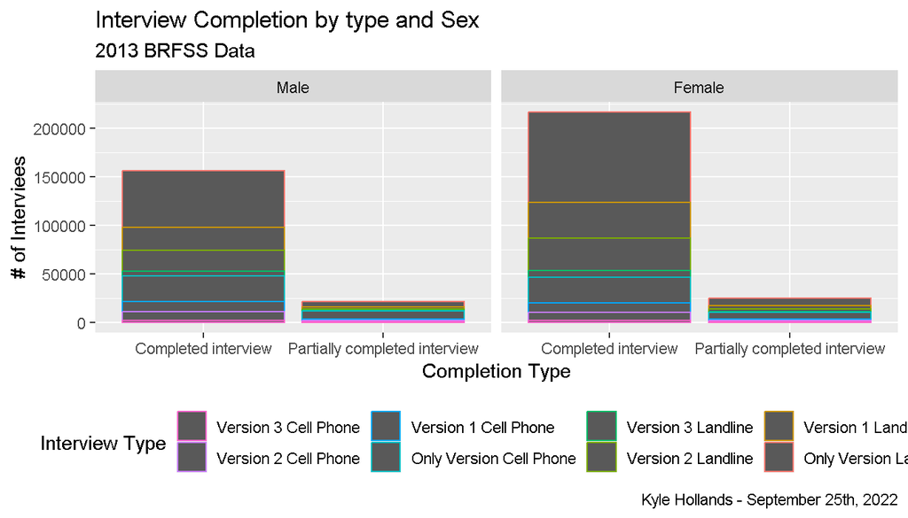

```r
#compl_perc_state <- with(trimmed_brfss2013, table( state, compl_type)) %>%
#prop.table(margin = 1)
#compl_perc_state

# Plot
ggplot(data = trimmed_brfss2013, aes(x = compl_type)) +
  guides(col = guide_legend(reverse = TRUE)) +
  geom_bar(data = trimmed_brfss2013, aes(color = int_type)) +
  facet_grid(. ~ sex) +
  theme(legend.position = "bottom") +
  labs(
    x = "Completion Type", y = "# of Interviees",
    title = "Interview Completion by type and Sex",
    subtitle = "2013 BRFSS Data",
    caption = "Kyle Hollands - September 25th, 2022",
    color="Interview Type"
  )
```

```r
ggsave(
  'Interview Completion by type and Sex.png',
  plot = last_plot(),
  scale = 1,
  width = 8,
  height = 8,
  dpi = 500,
  limitsize = FALSE,
  bg = NULL
  )
```